# Simple Exponential Smoothing in R

Week 12 R-lab  
Zhaohu(Jonathan) Fan

07/27/2021

# Forecasting Method(s)

- 1. Define Goal
- 2. Get Data
- 3. Explore & Visualize Series
- 4. Pre-Process Data
- 5. Partition Series
- 6. $\color{red}{\text{Apply Forecasting Method(s): Simple Exponential Smoothing}}$
- 7. Evaluate & Compare Performance
- 8. Implement Forecasts/System

# How It Differs

- Naïve model
  - Forecasts equal to last observed value.
  - Forecasts: $\hat{y}_{T+h|T} =y_T$.
- Seasonal naïve model
  - Forecasts equal to last value from same season.

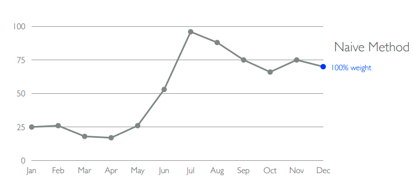

# How It Differs (cont’d)

- Forecasts equal to average of historical data (several observed values).

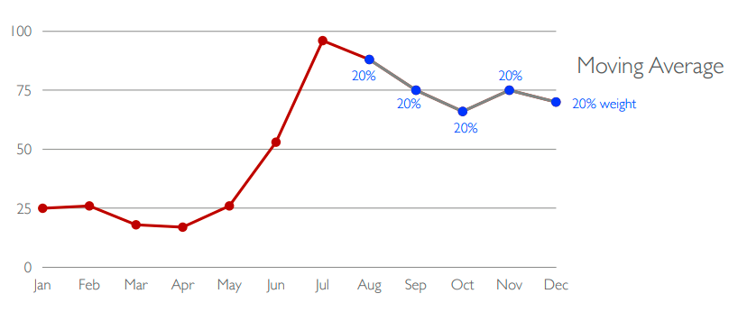

# How It Differs (cont’d)

- The more recent the observation, the higher the associated weight.

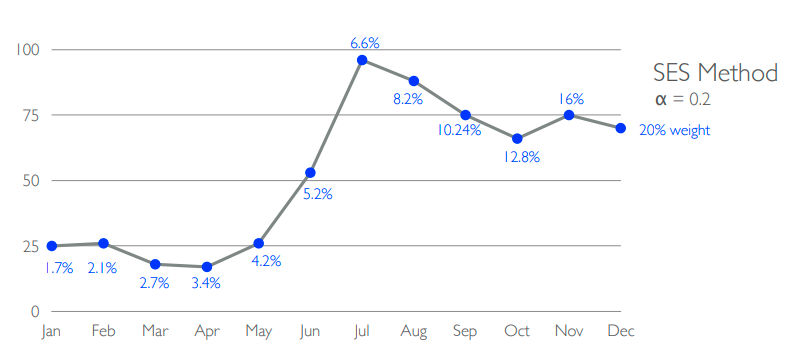

# The Equation

- Forecasts produced using exponential smoothing methods are $\color{blue}{\text{weighted averages of past observations}}$, with the$\color{blue}{\text{ weights decaying exponentially as the observations get older}}$.

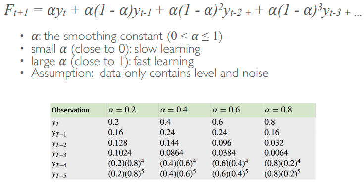

# Choosing the Smoothing Constant

- Best approach: choose the $\alpha$ that minimizes prediction error!

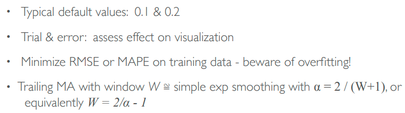

# But What About Trends & Seasonality?

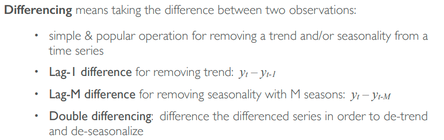

# Differencing Summary

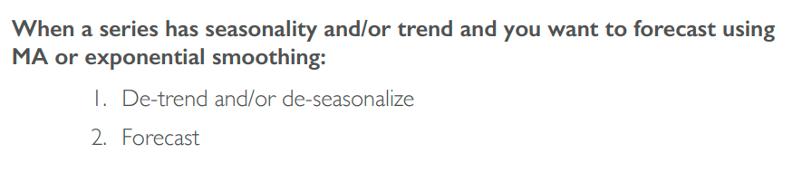

# Data Example (Let’s practice!)

Our goal is to use the data set ‘books.csv’ to forecast the next four day’s sales for paperback books.

Step 1: Load packages used

```r
library(tidyverse)
library(fpp2)
```

Step 2: Import and convert paperback to time series object

```r
setwd("C:/Users/fanzh/OneDrive - University of Cincinnati/UC_couse/000_Teaching_4090_SS21/Labs/Week12")
books <- read_csv("books.csv")
head(books,5)
```

```
## # A tibble: 5 x 3
##     Day Paperback Hardcover
##   <dbl>     <dbl>     <dbl>
## 1     1       199       139
## 2     2       172       128
## 3     3       111       172
## 4     4       209       139
## 5     5       161       191
```

```r
paper.ts <- ts(books["Paperback"], start = 1, frequency = 1)
```

Note: Use of “[ ]” for subsetting and indexing

# Data Example (cont’d)

Step 3: Plot the paperback series

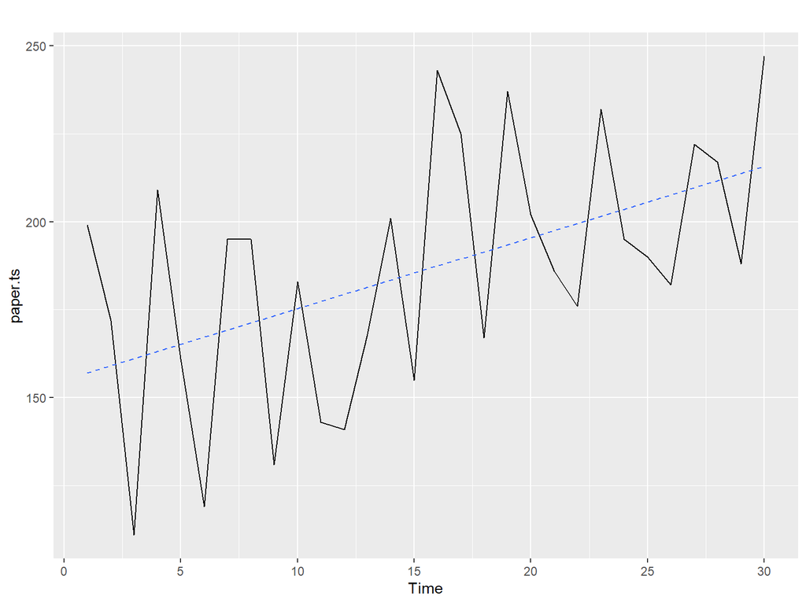

```r
autoplot(paper.ts) + geom_smooth(method = "lm", linetype = "dashed", se = FALSE, size = .5)
```

- The data has upward trend, which is probably linear.
- The data has cyclic structure, although seasonality is not present.

# Data Example (cont’d)

Step 4: Partition the data so that the last four observations are used for your test data

```r
library(forecast)
# partition
paper_train <- subset(paper.ts,end = length(paper.ts)- 4)
paper_test <- subset(paper.ts,start = length(paper.ts) - 3)

paper_train
```

```
## Time Series:
## Start = 1
## End = 26
## Frequency = 1
##  [1] 199 172 111 209 161 119 195 195 131 183 143 141 168 201 155 243 225 167 237
## [20] 202 186 176 232 195 190 182
```

```r
paper_test
```

```
## Time Series:
## Start = 27
## End = 30
## Frequency = 1
## [1] 222 217 188 247
```

# Data Example (cont’d)

Step 5: Use simple exponential smoothing and explore different values of $\alpha$ (.1, .2, .3, etc). Record the test prediction RMSE for the forecasts. How does $\alpha$ affect the forecasts?

Perform SES with alpha = .1, .2, .3

```r
ses.1 <- ses(paper_train, alpha = 0.1, h = 4)
ses.2 <- ses(paper_train, alpha = 0.2, h = 4)
ses.3 <- ses(paper_train, alpha = 0.3, h = 4)
```

# Data Example (cont’d)

Step 6: Assess prediction accuracy:

```r
accuracy(ses.1, paper_test)
```

```
##                     ME     RMSE      MAE        MPE     MAPE      MASE
## Training set  5.942452 34.13232 26.96938 -0.4295321 15.61521 0.6629641
## Test set     29.104802 35.86558 29.80240 12.4969025 12.86797 0.7326057
##                    ACF1 Theil's U
## Training set -0.1160565        NA
## Test set     -0.4716847 0.9675242
```

```r
accuracy(ses.2, paper_test)
```

```
##                     ME     RMSE      MAE       MPE     MAPE      MASE
## Training set  4.490054 34.26272 28.43388 -1.082746 16.42398 0.6989645
## Test set     24.740097 32.42410 27.62005 10.480351 12.01224 0.6789589
##                    ACF1 Theil's U
## Training set -0.2169554        NA
## Test set     -0.4716847 0.8866256
```

```r
accuracy(ses.3, paper_test)
```

```
##                     ME     RMSE      MAE       MPE     MAPE      MASE
## Training set  2.685266 35.06664 29.87898 -2.080051 17.34698 0.7344883
## Test set     25.458492 32.97552 27.97925 10.812259 12.15309 0.6877887
##                    ACF1 Theil's U
## Training set -0.2737697        NA
## Test set     -0.4716847 0.8995712
```

# Data Example (cont’d)

Step 7: Let’s automate this process and assess alpha 0.01 - 0.99:

```r
# First, I create a vector of values from 0.01 to 0.99 with step 0.01
alpha <- seq(0.01, 0.99, 0.01)
```

Initialization of variable RMSE with a single value NA.

```r
RMSE <- NA
```

Iterate through all values of vector alpha and assess prediction accuracy

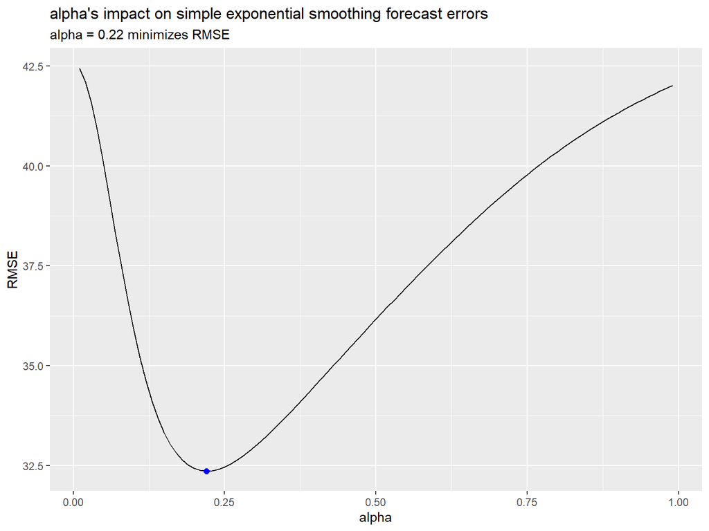

```r
for(i in seq_along(alpha)) {
  fcast <- ses(paper_train, alpha = alpha[i], h = 4)
  RMSE[i] <- accuracy(fcast, paper_test)[2, 2]
}

# turn our RMSE values for alpha .01-.99 into a data frame
error <- data_frame(alpha, RMSE)
minimum <- filter(error, RMSE == min(RMSE))

# plot RMSE values for alpha .01-.99
ggplot(error, aes(alpha, RMSE)) +
  geom_line() +
  geom_point(data = minimum, color = "blue", size = 2) +
  ggtitle("alpha's impact on simple exponential smoothing forecast errors",
          subtitle = "alpha = 0.22 minimizes RMSE")
```

# Data Example (cont’d)

Step 8: Now let the R select the optimal alpha value. Use this value to generate forecasts for the next four days. Compare results with auto select model:

```r
ses.auto <- ses(paper_train, h = 4)
summary(ses.auto)
```

```
##
## Forecast method: Simple exponential smoothing
##
## Model Information:
## Simple exponential smoothing
##
## Call:
##  ses(y = paper_train, h = 4)
##
##   Smoothing parameters:
##     alpha = 0.1351
##
##   Initial states:
##     l = 171.713
##
##   sigma:  35.4645
##
##      AIC     AICc      BIC
## 274.1931 275.2840 277.9674
##
## Error measures:
##                    ME    RMSE      MAE        MPE     MAPE      MASE       ACF1
## Training set 5.740754 34.0732 27.41353 -0.4571133 15.81877 0.6738824 -0.1616501
##
## Forecasts:
##    Point Forecast    Lo 80    Hi 80    Lo 95    Hi 95
## 27       191.8781 146.4285 237.3277 122.3690 261.3873
## 28       191.8781 146.0156 237.7406 121.7375 262.0188
## 29       191.8781 145.6064 238.1498 121.1116 262.6446
## 30       191.8781 145.2008 238.5555 120.4913 263.2650
```

```r
# optimal alpha for prediction accuracy (based on above for loop results)
ses.optimal <- ses(paper_train, alpha = .22, h = 4)

accuracy(ses.auto, paper_test)
```

```
##                     ME     RMSE      MAE        MPE     MAPE      MASE
## Training set  5.740754 34.07320 27.41353 -0.4571133 15.81877 0.6738824
## Test set     26.621870 33.88176 28.56094 11.3497551 12.38117 0.7020879
##                    ACF1 Theil's U
## Training set -0.1616501        NA
## Test set     -0.4716847 0.9208597
```

```r
accuracy(ses.optimal, paper_test)
```

```
##                     ME     RMSE      MAE       MPE     MAPE      MASE
## Training set  4.085371 34.38411 28.72038 -1.299844 16.60708 0.7060073
## Test set     24.654625 32.35893 27.57731 10.440862 11.99548 0.6779084
##                    ACF1 Theil's U
## Training set -0.2300195        NA
## Test set     -0.4716847  0.885096
```

# Data Example (cont’d)

Step 9: Plot the forecasted values with the alpha that minizes the prediction error:

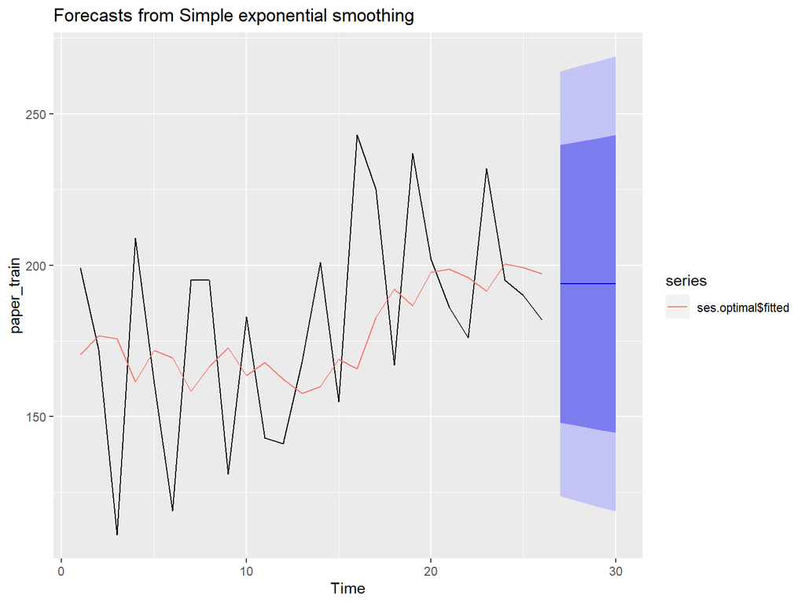

```r
autoplot(ses.optimal) +
  autolayer(ses.optimal$fitted)
```